# Intro to spatial data-Miscellaneous tips

Fabiola Rodríguez

July 2018

This document shares resources and examples on some basic spatial data manipulation in R. The goal is to expose people familiar with R to geospatial data, what it is, and how it is used. This document was written by pooling multiple resources presented below and/or referenced in the content.

### Resources: spatial data, tutorials, etc.

Sources to start with spatial data processing are found here:

1. http://www.rspatial.org/
2. https://www.neonscience.org/dc-shapefile-attributes-r
3. https://www.neonscience.org/raster-data-r
4. http://www.mikemeredith.net/blog/1212_GIS_layer_for_Distance_from.htm
5. http://www.milanor.net/blog/maps-in-r-plotting-data-points-on-a-map/

Sources for land cover classifications:

6. https://fromgistors.blogspot.com/p/semi-automatic-classification-plugin.html
7. https://earthenginepartners.appspot.com/science-2013-global-forest
8. http://www.globallandcover.com/GLC30Download/index.aspx
9. https://gapanalysis.usgs.gov/gaplandcover/data/download/

Sources for climatic, elevation models, and other data:

10. http://www.worldclim.org/bioclim
11. https://lpdaac.usgs.gov/data_access/gdex
12. https://cims.coastal.louisiana.gov/monitoring-data/
13. http://sinit.hn/#

USA counties and roads:

14. https://www.census.gov/geo/maps-data/data/cbf/cbf_counties.html
15. https://catalog.data.gov/dataset/tiger-line-shapefile-2016-nation-u-s-primary-roads-national-shapefile

Information on the packages used in this guide:

16. https://cran.r-project.org/web/packages/raster/raster.pdf
17. https://cran.r-project.org/web/packages/rgdal/index.html
18. https://cran.r-project.org/web/packages/sp/index.html
19. https://cran.r-project.org/web/packages/geosphere/geosphere.pdf

Another platform to conduct analysis or view geospatial information is QGIS which is free and available at:

20. https://qgis.org/en/site/forusers/download.html

### R libraries used in this guide

```r
if (!require(readr)) install.packages('readr')
suppressWarnings(suppressMessages(library(readr)))

if (!require(raster)) install.packages('raster')
suppressWarnings(suppressMessages(library(raster))) # For data manupulation, reading, and writing of data such as rasters

if (!require(rgdal)) install.packages('rgdal')
```

[output not shown]

```r
suppressWarnings(suppressMessages(library(rgdal))) # Geospatial data loading and manipulation (e.g. load shapefiles)

if (!require(sp)) install.packages('sp')
suppressWarnings(suppressMessages(library(sp))) #Converts  data frames to spatial files, plots maps, prints, summarizes

if (!require(geosphere)) install.packages('geosphere')
suppressWarnings(suppressMessages(library(geosphere))) # Computations of several aspects of distance, direction, and area (e.g.calculates distances)
```

## Vector manipulation and analysis

- Add GPS points for a plant species found along the Gulf Coast of the United States. The data is a subset from multiple databases found in the Coastal Protection and Restoration Authority website (resource # 12). The *Aaustralis* file reflects data from the herbaceous marsh database and summarized hydrographic data:

```r
Aaustralis <- read_csv("data/Aaustralis.csv") # Load the data
```

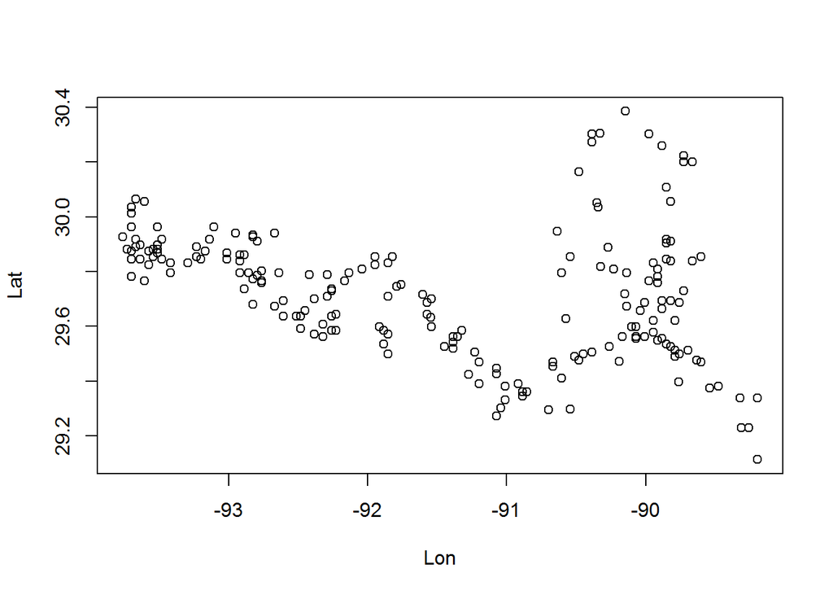

```r
Aaustralis.points <- as.data.frame(Aaustralis[,19:20]) # Select the coordinate columns
Aaustralis.points <- Aaustralis.points[!duplicated(Aaustralis.points),] # Eliminate duplicate coordinates

plot(Aaustralis.points$Longitude,Aaustralis.points$Latitude, xlab="Lon", ylab="Lat")
```

- Add polygons and lines (from the United States Census Bureau-resources #14 and 15):

```r
Roads<-readOGR("vectors/tl_2016_us_primaryroads.shp")
US.counties<-readOGR("vectors/cb_2017_us_county_5m.shp")
US.counties # View metadata summary
```

```
## class       : SpatialPolygonsDataFrame
## features    : 3233
## extent      : -179.1473, 179.7785, -14.55255, 71.35256  (xmin, xmax, ymin, ymax)
## coord. ref. : +proj=longlat +datum=NAD83 +no_defs +ellps=GRS80 +towgs84=0,0,0
## variables   : 9
## names       : STATEFP, COUNTYFP, COUNTYNS,       AFFGEOID, GEOID,    NAME, LSAD,      ALAND,   AWATER
## min values  :      01,      001, 00023901, 0500000US01001, 01001, AÃ±asco,   00, 1000508765,        0
## max values  :      78,      840, 02516404, 0500000US78030, 78030, Ziebach,   25, 9985057446, 99965171
```

- You can also access the attribute table of the shapefile:

```r
head(US.counties@data)
```

```
##   STATEFP COUNTYFP COUNTYNS       AFFGEOID GEOID       NAME LSAD
## 0      04      015 00025445 0500000US04015 04015     Mohave   06
## 1      22      105 00559500 0500000US22105 22105 Tangipahoa   15
## 2      16      063 00395624 0500000US16063 16063    Lincoln   06
## 3      27      119 00659505 0500000US27119 27119       Polk   06
## 4      38      017 01034226 0500000US38017 38017       Cass   06
## 5      46      081 01266996 0500000US46081 46081   Lawrence   06
##         ALAND    AWATER
## 0 34475503964 387344307
## 1  2049488093 136678798
## 2  3111451190  11606076
## 3  5105067510  69169913
## 4  4571107601   7732062
## 5  2072127374    667509
```

- These are the names of the headers from the attribute table:

```r
names(US.counties@data)
```

```
## [1] "STATEFP"  "COUNTYFP" "COUNTYNS" "AFFGEOID" "GEOID"    "NAME"
## [7] "LSAD"     "ALAND"    "AWATER"
```

- US counties:

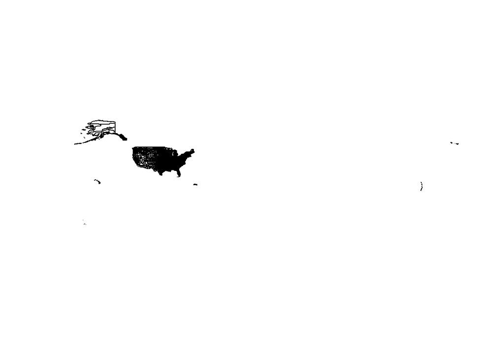

```r
plot(US.counties)
```

- Select and subset Louisiana counties:

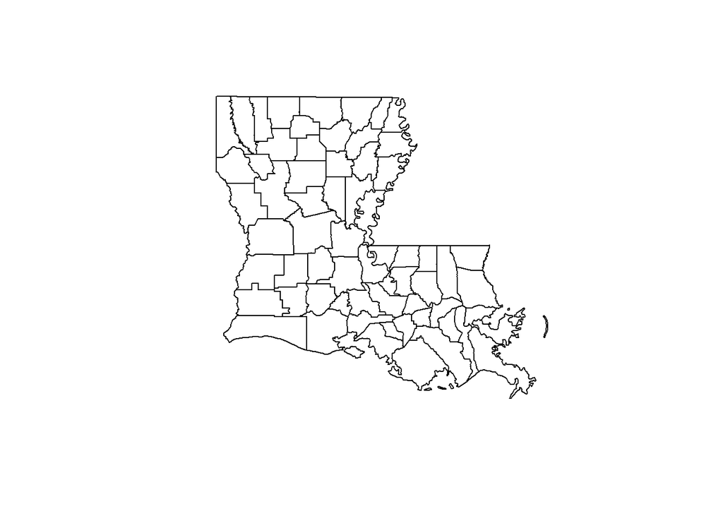

```r
LA<-US.counties[US.counties$STATEFP == 22,]
plot(LA)
```

- Subset the roads that intersect Louisiana:

```r
Roads.LA<-intersect(Roads, LA)
```

- Plot a specific part of Louisiana:

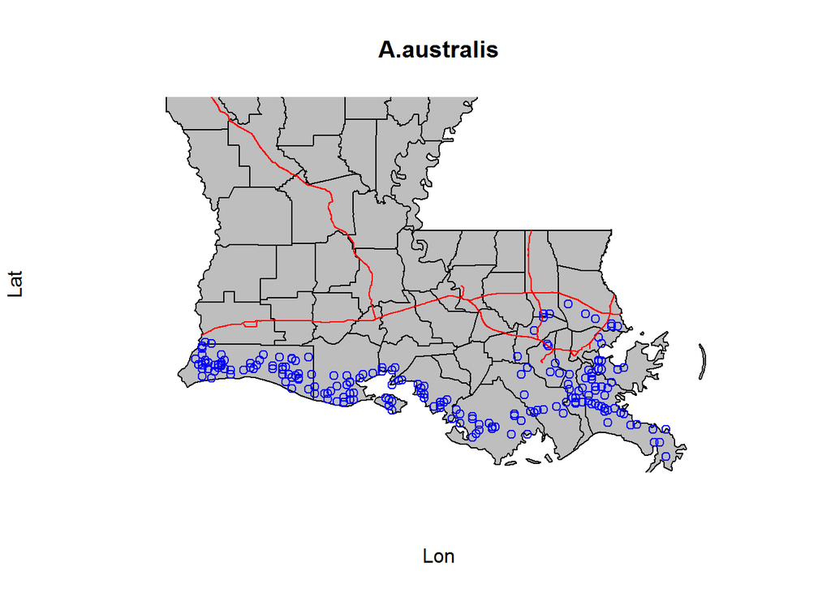

```r
plot(LA, xlim=c(-93.8, -89.0), ylim=c(29.1, 32), xlab="Lon", ylab="Lat", main="A.australis", col="gray")
points(Aaustralis.points$Longitude,Aaustralis.points$Latitude, col="blue")
lines(Roads.LA, col="red")
```

- Select points by location and save to new file:

```r
# Because x (Lon) and y (Lat) are reversed in Aaustralis.points columns
x<-Aaustralis.points$Longitude
y<-Aaustralis.points$Latitude
A.points<-cbind(x,y)
A.points.shape<-SpatialPoints(A.points) # This creates a shapefile

# Subset a county in Louisiana
PLA<-LA[LA$NAME == "Plaquemines",]
proj4string(A.points.shape)<-proj4string(PLA) # Double check if indeed both are in the same reference system. We know PLA but assume Aaustralis is in the same

Australis.Plaq<-A.points.shape[complete.cases(over(A.points.shape,PLA)),]  # Select the points that are intersecting with the Plaquemines county

length(Australis.Plaq) # Amount of points that were subset of Aaustralis in Plaquemines county, Louisiana
```

```
## [1] 32
```

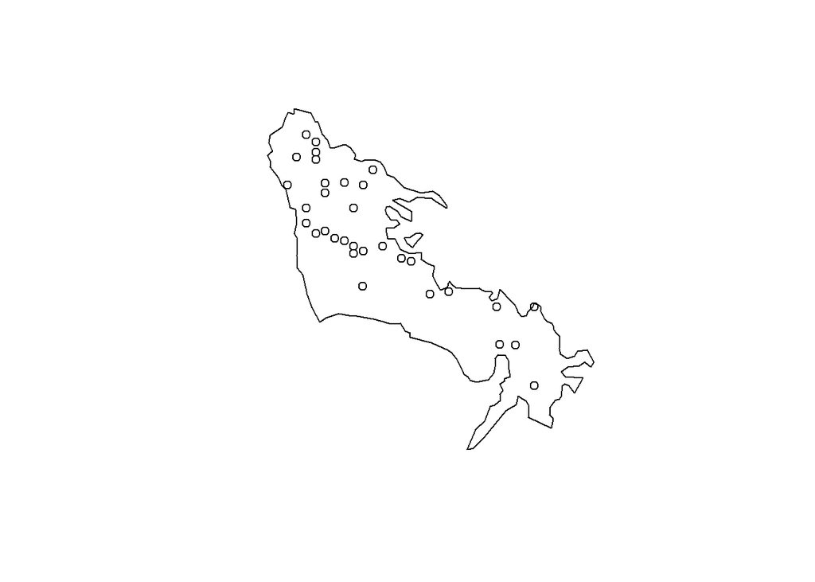

```r
plot(PLA)
points(Australis.Plaq)
```

- Quantify nearest distance between all points:

```r
Dist.matrix<-distm(A.points.shape) # Distances in meters, default assumed datum is WGS84, so must convert to one of the supported datums specified in the "geosphere" library
Dist.matrix[1:5,3] # Show a bit of the matrix
```

```
## [1]  5396.419  3218.188     0.000 75404.328 73484.359
```

```r
Dist.matrix.Aaustralis<-write.csv(Dist.matrix, file="DM_Aaustralis.csv")
```